# RStudio-help

Steve Simon

December 7, 2018

## Introduction

This talk will cover some of the help features built into RStudio.

## The autocomplete feature

[figure not shown]

Screenshot of autocompletion of a variable name

RStudio has a nice autocomplete feature, which allows you to use long variable names without having to retype everything.

## Autocomplete feature for functions

[figure not shown]

Screenshot of autocompletion of a function name

When you use autocomplete on a function, popup window lists the possible autocomplete choices AND a brief listing of the variables in the function AND a brief explanation of what the file does.

## Help on functions within libraries

[figure not shown]

Screenshot of a failed search for help

One nice feature in RStudio is searching for help for functions in libaries. If you are looking for help for the join function in dplyr, but you have not loaded dplyr yet with the library function, you will not get an answer.

## Help tab to the rescue!

[figure not shown]

Screenshot of help tab

But when you ask for help on the same function within the help tab, it provides help, provided you have installed the proper package.

## The help menu in RStudio

[figure not shown]

Screenshot of help menu choices

You have a lot of extra choices available to you in the help menu.

## R Help

[figure not shown]

Screenshot of R Help submenu

You can get links to a variety of web resources with the R Help submenu.

## RStudio docs submenu

[figure not shown]

Screenshot of RStudio docs submenu

## RStudio Community Forum

[figure not shown]

Screenshot of RStudio Community Forum

I have not used the RStudio Community Forum.

## RStudio support

[figure not shown]

Screenshot of RStudio support web page

I have also not used RStudio support. It appears to be a more technical forum that RStudio Community Forum.

## Cheatsheets

[figure not shown]

Screenshot of major cheat sheet choices from the Help menu

Cheat sheets are one or two page PDF documents packed with summaries about various aspects of R and RStudio. I wrote one of these cheat sheets, “How Big is Your Graph”.

## Help menu: Keyboard shortcuts

[figure not shown]

Screenshot of keyboard shortcuts

RStudio has a million different keyboard shortcuts. I only use a few of them, but you might find some of these helpful.

## Help menu: Markdown Quick Reference

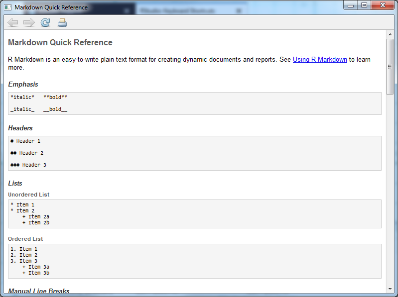

## Help menu: Roxygen Quick Reference

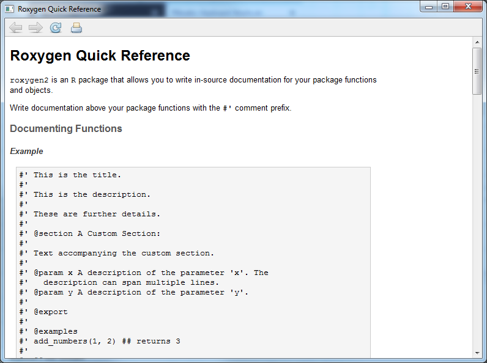

Screenshot of Roxygen Quick Reference

I have not used Roxygen, the R based system for documentation based on the Oxygen standard.

## Summary

RStudio offers a variety of help resources above and beyond what is available in R. These can be found in

- The autocomplete feature for function names,
- The Help tab
- The Help menu